# Logistic Regression using WoE Grouping

1. [Importing Libraries](#1)
2. [Load WoE data](#2)
3. [Creating Training Data](#3)
4. [Reducing Training Data](#4)
5. [Variable Selection](#5)
6. [KS Function to evaluate](#6)
7. [Logistic Regression Code - Functionalised](#7)
8. [Stepwise Regression](#8)
9. [Output of the final iteration data](#9)
10. [Visualisation of results](#10)
11. [Gini of Test data ](#11)
12. [Score Distribution](#12)
13. [KS Plot](#13)
14. [Cumulative Score Distribution Plots](#14)
15. [Comparison to Incumbent Model](#15)
16. [Comparison to Lasso](#16)

# Importing Libraries

This step imports the libraries necessary to use various functionality:

1. Pandas - Creation and manipulation Dataframes (the object table data is stored in)
2. Numpy - required for Pandas
3. Sklearn - Optimisation, machine learning and other algorithms

Own functionality:

1. load_behavioural_s3
2. load_behavioural_woe_s3
3. getUniGiniCorr

```python
import pandas as pd
import numpy as np
import matplotlib.pyplot as plt
from sklearn.preprocessing import LabelEncoder
from getUniGiniCorr import getUniGiniCorr
from load_behavioural_s3 import load_behavioural_s3
from load_behavioural_woe_s3 import load_behavioural_woe_s3
from sklearn.model_selection import train_test_split

from sklearn.linear_model import LogisticRegression
from sklearn.feature_selection import RFE
from sklearn import datasets
from sklearn.metrics import roc_auc_score

#sample_data = pd.read_csv("GN_AWS_BEHAVIOURAL.csv",low_memory=False)
#df0 = pd.DataFrame(sample_data)
```

# Loading Full WoE Data

To speed the modelling up we have separated out the grouping and calculation of WoE to a previous step and are loadin the pre processed WoE dataset. The function load_behavioural_s3() loads the original dataset. The function load_behavioural_woe_s3() loads the dataset that contains the woe mapping.

```python
#S3 loading -explicitly delienates schema of table and hence very memory efficient
# full_data = load_behavioural_s3()
# full_data.info(memory_usage='deep')

#now using woe data to start with
full_data = load_behavioural_woe_s3()
full_data.info(memory_usage='deep')


# dfs3 = load_behavioural_s3()
# dfs3.info(memory_usage='deep')
# dfs3.head()
```

```
None
smart_open package not installed
Starting new HTTP connection (1): 169.254.169.254
Starting new HTTP connection (1): 169.254.169.254
Starting new HTTPS connection (1): s3.eu-west-1.amazonaws.com
Starting new HTTPS connection (2): s3.eu-west-1.amazonaws.com
<class 'pandas.core.frame.DataFrame'>
RangeIndex: 52623 entries, 0 to 52622
Columns: 2462 entries, Unnamed: 0 to SUM_EQ_NSC135_WoE
dtypes: category(348), float32(2106), object(1), uint16(2), uint8(5)
memory usage: 506.4 MB
```

# Creating Training Data

The next cell creates a random split into train (70%) and test (30%) data. The split is reproducable using the same random seed 9999.

The cell after that validates the percentage reserved for testing.

```python
train, test = train_test_split(full_data, test_size=0.3, random_state=9999 )
#train.head
```

```python
# verifying volumes
print(test.shape)
print(train.shape)
print('Test Ratio',test.shape[0]/(train.shape[0]+test.shape[0]))
```

```
(15787, 2462)
(36836, 2462)
Test Ratio 0.3000019003097505
```

# Reducing Training Data

Removing Variables that only have a single value as we cannot calculate a meaningful Gini. The data contains WoE grouping with no meaningful variation for some variables.

```python
# counting the number of categories in the training dataset
# T transposes the whole dataset into a dataset with 1300 rows and 50k columns.
# The inline function we apply counts the number of unique values along columns, i.e. axis 1.

cats = train.T.apply(lambda x: x.nunique(), axis=1)
```

```python
# Finding Variables with single values and excluding them as they will not be predictive

cats_df = pd.DataFrame(cats, columns = ['unique_vals'])
single_val_vars = list(cats_df[cats_df.unique_vals <= 1].reset_index().loc[:,'index'])

print('Number of variables with no variation:',len(single_val_vars))

#print((single_val_vars))

#cols plus are all columns from train that have WoE in the title + bad flag
cols_plus = [k for k in train.columns.get_values() if 'WoE' in k]+['bad_flag']

print('Number of WoE variables:',len(cols_plus))
var_removed = []
var_not_removed = []

# This loop excludes the variables found in the list of single_val_vars from cols_plus
# if the variable is no longer in cols_plus is will be appended to var_not_removed
for x in single_val_vars:
    try:
        cols_plus.remove(x)
        var_removed.append(x)
    except: var_not_removed.append(x)

#cols are all columns from cols_plus that have WoE in the title
cols = [k for k in cols_plus if 'WoE' in k]

print('Number of variables including bad flag:',len(cols_plus))
print('Number of variables excluding bad flag:',len(cols))
print('Number of variables removed:',len(var_removed))

#train = train.loc[:, cols_plus]

print('is sample_weight in teh variables:','sample_weight' in cols_plus)

ginicorr_results=getUniGiniCorr(train.loc[:,cols_plus])
ginicorr_results
#ginicorr
#cats_df
```

```
Number of variables with no variation: 249
Number of WoE variables: 1231
Number of variables including bad flag: 1106
Number of variables excluding bad flag: 1105
Number of variables removed: 125
is sample_weight in teh variables: False
1
1
```

|  | Variable | Gini | Gini_abs | Corr | p_value | Corr_type | Corr_abs |
| --- | --- | --- | --- | --- | --- | --- | --- |
| 1105 | bad_flag | 1.000000 | 1.000000 | 1.000000 | 0.000000e+00 | Kendall | 1.000000 |
| 1106 | bad_flag | 1.000000 | 1.000000 | 1.000000 | 0.000000e+00 | Kendall | 1.000000 |
| 458 | MAX_EX_E5_S_05_2_ALL_WoE | -0.554290 | 0.554290 | -0.453293 | 0.000000e+00 | Pearson | 0.453293 |
| 459 | AVG_EX_E5_S_05_2_ALL_WoE | -0.554020 | 0.554020 | -0.453427 | 0.000000e+00 | Pearson | 0.453427 |
| 457 | MIN_EX_E5_S_05_2_ALL_WoE | -0.553766 | 0.553766 | -0.453356 | 0.000000e+00 | Pearson | 0.453356 |
| 206 | AVG_436_CSL_MEB_CURR_BAL_1_WoE | -0.486877 | 0.486877 | -0.410778 | 0.000000e+00 | Pearson | 0.410778 |
| 204 | MIN_436_CSL_MEB_CURR_BAL_1_WoE | -0.484903 | 0.484903 | -0.408840 | 0.000000e+00 | Pearson | 0.408840 |
| 205 | MAX_436_CSL_MEB_CURR_BAL_1_WoE | -0.484269 | 0.484269 | -0.409029 | 0.000000e+00 | Pearson | 0.409029 |
| 207 | SUM_436_CSL_MEB_CURR_BAL_1_WoE | -0.479010 | 0.479010 | -0.404851 | 0.000000e+00 | Pearson | 0.404851 |
| 433 | MIN_CC_OI_SCORE_WoE | -0.468375 | 0.468375 | -0.393929 | 0.000000e+00 | Pearson | 0.393929 |
| 210 | AVG_437_CSL_AVG_CURR_BAL_3_WoE | -0.467988 | 0.467988 | -0.394204 | 0.000000e+00 | Pearson | 0.394204 |
| 208 | MIN_437_CSL_AVG_CURR_BAL_3_WoE | -0.466659 | 0.466659 | -0.392462 | 0.000000e+00 | Pearson | 0.392462 |
| 209 | MAX_437_CSL_AVG_CURR_BAL_3_WoE | -0.465980 | 0.465980 | -0.393428 | 0.000000e+00 | Pearson | 0.393428 |
| 435 | AVG_CC_OI_SCORE_WoE | -0.465080 | 0.465080 | -0.389901 | 0.000000e+00 | Pearson | 0.389901 |
| 434 | MAX_CC_OI_SCORE_WoE | -0.463456 | 0.463456 | -0.388835 | 0.000000e+00 | Pearson | 0.388835 |
| 211 | SUM_437_CSL_AVG_CURR_BAL_3_WoE | -0.459646 | 0.459646 | -0.387894 | 0.000000e+00 | Pearson | 0.387894 |
| 687 | MAX_char3425_WoE | -0.457156 | 0.457156 | -0.374477 | 0.000000e+00 | Pearson | 0.374477 |
| 689 | SUM_char3425_WoE | -0.455612 | 0.455612 | -0.370215 | 0.000000e+00 | Pearson | 0.370215 |
| 688 | AVG_char3425_WoE | -0.455271 | 0.455271 | -0.373237 | 0.000000e+00 | Pearson | 0.373237 |
| 585 | SUM_char3138_WoE | -0.454809 | 0.454809 | -0.367560 | 0.000000e+00 | Pearson | 0.367560 |
| 583 | MAX_char3138_WoE | -0.454777 | 0.454777 | -0.371142 | 0.000000e+00 | Pearson | 0.371142 |
| 202 | AVG_435_CSLM_AVG_CURR_BAL_3_WoE | -0.452817 | 0.452817 | -0.377106 | 0.000000e+00 | Pearson | 0.377106 |
| 230 | AVG_445_CSLM_AVG_CURR_BAL_3_WoE | -0.452817 | 0.452817 | -0.377106 | 0.000000e+00 | Pearson | 0.377106 |
| 174 | AVG_420_CA_MEB_CURR_BAL_1_WoE | -0.452601 | 0.452601 | -0.380255 | 0.000000e+00 | Pearson | 0.380255 |
| 584 | AVG_char3138_WoE | -0.452371 | 0.452371 | -0.369698 | 0.000000e+00 | Pearson | 0.369698 |
| 18 | AVG_117_CLOSING_BALANCE_WoE | -0.452214 | 0.452214 | -0.379714 | 0.000000e+00 | Pearson | 0.379714 |
| 201 | MAX_435_CSLM_AVG_CURR_BAL_3_WoE | -0.452192 | 0.452192 | -0.376518 | 0.000000e+00 | Pearson | 0.376518 |
| 229 | MAX_445_CSLM_AVG_CURR_BAL_3_WoE | -0.452192 | 0.452192 | -0.376518 | 0.000000e+00 | Pearson | 0.376518 |
| 588 | AVG_char3140_WoE | -0.451967 | 0.451967 | -0.363897 | 0.000000e+00 | Pearson | 0.363897 |
| 587 | MAX_char3140_WoE | -0.451839 | 0.451839 | -0.362428 | 0.000000e+00 | Pearson | 0.362428 |
| ... | ... | ... | ... | ... | ... | ... | ... |
| 1025 | Excl_reason_WoE | -0.030960 | 0.030960 | -0.030146 | 7.168218e-09 | Pearson | 0.030146 |
| 999 | MAX_CC_NN_WoE | -0.029741 | 0.029741 | -0.046817 | 2.472193e-19 | Pearson | 0.046817 |
| 423 | SUM_98_CA_TOT_LOWEST_BAL_WoE | -0.029245 | 0.029245 | -0.062624 | 2.452938e-33 | Pearson | 0.062624 |
| 422 | AVG_98_CA_TOT_LOWEST_BAL_WoE | -0.029169 | 0.029169 | -0.060776 | 1.713220e-31 | Pearson | 0.060776 |
| 908 | SUM_CC_PN_WoE | -0.029077 | 0.029077 | -0.046190 | 7.341748e-19 | Pearson | 0.046190 |
| 1000 | AVG_CC_NN_WoE | -0.029071 | 0.029071 | -0.046535 | 4.043458e-19 | Pearson | 0.046535 |
| 420 | MIN_98_CA_TOT_LOWEST_BAL_WoE | -0.029040 | 0.029040 | -0.058809 | 1.368170e-29 | Pearson | 0.058809 |
| 869 | SUM_EQ_FSC200_WoE | -0.028886 | 0.028886 | -0.038193 | 2.256596e-13 | Pearson | 0.038193 |
| 981 | MIN_CC_NN_WoE | -0.028784 | 0.028784 | -0.046441 | 4.753684e-19 | Pearson | 0.046441 |
| 782 | MAX_CC_UZ_WoE | -0.028651 | 0.028651 | -0.047362 | 9.470178e-20 | Pearson | 0.047362 |
| 1095 | MIN_CC_UZ_WoE | -0.028592 | 0.028592 | -0.047360 | 9.509636e-20 | Pearson | 0.047360 |
| 836 | AVG_CC_UZ_WoE | -0.028592 | 0.028592 | -0.047349 | 9.689649e-20 | Pearson | 0.047349 |
| 421 | MAX_98_CA_TOT_LOWEST_BAL_WoE | -0.027787 | 0.027787 | -0.042060 | 6.703682e-16 | Pearson | 0.042060 |
| 785 | SUM_CC_UZ_WoE | -0.027359 | 0.027359 | -0.048151 | 2.319479e-20 | Pearson | 0.048151 |
| 445 | MIN_EQ_FSC9_WoE | -0.025323 | 0.025323 | -0.018956 | 2.743790e-04 | Pearson | 0.018956 |
| 843 | MAX_CC_CU_WoE | -0.017820 | 0.017820 | -0.042955 | 1.614423e-16 | Pearson | 0.042955 |
| 1096 | AVG_CC_CU_WoE | -0.017781 | 0.017781 | -0.042934 | 1.668649e-16 | Pearson | 0.042934 |
| 944 | MIN_CC_CU_WoE | -0.017360 | 0.017360 | -0.042859 | 1.882670e-16 | Pearson | 0.042859 |
| 440 | SUM_CC_address_match_success_WoE | -0.017284 | 0.017284 | -0.019375 | 2.002079e-04 | Pearson | 0.019375 |
| 447 | AVG_EQ_FSC9_WoE | -0.017266 | 0.017266 | -0.013636 | 8.869106e-03 | Pearson | 0.013636 |
| 446 | MAX_EQ_FSC9_WoE | -0.016689 | 0.016689 | -0.013788 | 8.139065e-03 | Pearson | 0.013788 |
| 500 | SUM_EX_SP_B2_21_WoE | -0.016623 | 0.016623 | -0.019547 | 1.755072e-04 | Pearson | 0.019547 |
| 1073 | EQ_ADDRESS_MATCH_SUCCESS_WoE | -0.009362 | 0.009362 | -0.044485 | 1.322397e-17 | Pearson | 0.044485 |
| 437 | MIN_CC_address_match_success_WoE | -0.006735 | 0.006735 | -0.011389 | 2.883307e-02 | Pearson | 0.011389 |
| 438 | MAX_CC_address_match_success_WoE | -0.005470 | 0.005470 | -0.009574 | 6.613585e-02 | Pearson | 0.009574 |
| 439 | AVG_CC_address_match_success_WoE | -0.005470 | 0.005470 | -0.009574 | 6.613585e-02 | Pearson | 0.009574 |
| 308 | MIN_578_ACC_RECESS_UNEMPL_SCORE_WoE | -0.002913 | 0.002913 | -0.024667 | 2.191564e-06 | Pearson | 0.024667 |
| 788 | PRRS_517_BUILD_SOC_SAVER_1_WoE | -0.002033 | 0.002033 | -0.002212 | 6.712079e-01 | Pearson | 0.002212 |
| 309 | MAX_578_ACC_RECESS_UNEMPL_SCORE_WoE | -0.001349 | 0.001349 | -0.010076 | 5.312653e-02 | Pearson | 0.010076 |
| 310 | AVG_578_ACC_RECESS_UNEMPL_SCORE_WoE | -0.001349 | 0.001349 | -0.010076 | 5.312653e-02 | Pearson | 0.010076 |

1107 rows × 7 columns

# Variable Selection

Using Univariate Gini and Correlation with Target Variable. Variables are only retained if they have a univariate Gini of 0.05 and a correlation with the bad_flag higher than 0.05. In this case this is 1043 variables that are available for the model. We exclude the bad flag by hand from the variable selection as it is included in the dataset. This could be automated by excluding variables with a Gini greater than 0.99.

```python
gini_corr_vars=list(ginicorr_results['Variable'].loc[(ginicorr_results['Gini_abs'] >= 0.05) & ginicorr_results['Corr_abs']>=0.05])
```

```python
gini_corr_vars
print('Number of Variables retained for modelling:',len(gini_corr_vars))
```

```
Number of Variables retained for modelling: 1043
```

```python
#extracting the variable names
# bad flag is in the data and is exlcuded here.

final_vars = gini_corr_vars[2:]
regression_input = train.loc[:,['bad_flag']+final_vars].dropna()

#print(final_vars)
#regression_input
```

# KS Function to evaluate

This defines a basic function that is called later to calculate the KS value for each solution.

```python
# basic ks function
def ks_function(x):
    # taking a subset to keep things simple for functionalisation
    # bad flag can be a generic indicator whether the row belongs to distribution 1 or 2
    # score is an identifier of the distribution x - axis
    # a weight has to be added if input data is already grouped up
    ##sample = df_post.loc[:,['bad_flag','score']].copy()
    ##x = df_post.loc[:,['score','bad_flag']]
    col1 = x.columns[0]
    col2 = x.columns[1]
    # sort to have right order
    #sample.sort_values(by='score')
    x.sort_values(by=col1)

    # grouping by score and dropping level to get columns
    # assuming no missing values count gives # of distribution1+2, sum just # of distribution 1
    # count-sum gives # of distribution 2
    distr = x.groupby(col1).agg(['count','sum'])
    distr.columns = distr.columns.droplevel(0)
    distr['dis1'] = distr['sum']
    distr['dis2'] = distr['count'] - distr['sum']

    # calculating cumulative percentages
    distr['dis1_cum_sum'] = distr.dis1.cumsum()
    distr['dis1_perc'] = distr.dis1 / distr.dis1.sum()
    distr['dis1_cum_perc'] = distr.dis1_cum_sum/distr.dis1.sum()

    distr['dis2_cum_sum'] = distr.dis2.cumsum()
    distr['dis2_perc'] = distr.dis2 / distr.dis2.sum()
    distr['dis2_cum_perc'] = distr.dis2_cum_sum/distr.dis2.sum()

    # calculating KS
    distr['KS'] = distr['dis1_cum_perc'] - distr['dis2_cum_perc']
    KS = distr.KS.max()
    return KS
```

# Logistic Regression Code - Functionalised

This defines a function that expects a dataframe as input that contains a column with bad_flag and all variables that may appear in the variable_selection. The variable selection contains all variables that the logistic regression is fitted to. The model fit will use all variables provided. The fucntion hands back the variables included in the model, the coefficients of the variables, the KS and Gini of the model on the training data.

```python
#regression - basic function to called from stepwise algorithm
def regression_function(regression_input,variable_selection):
    x = regression_input[variable_selection].values       # independent variable
    y = regression_input['bad_flag'].values                      # dependent variable

    #print(x)
    #print(y)

    # instantiate a logistic regression model, and fit with X and y
    model = LogisticRegression(warm_start = True)
    model = model.fit(x, y)

    # check the accuracy on the training set
    model.score(x, y)
    a = model.predict(x)
    b = model.predict_proba(x)[:,0]

    # Scoring up the data
    predictions = pd.DataFrame(model.predict(x))
    #probabilities = model.predict_log_proba(regression_input[variable_selection].values)[:,1]
    log_probabilities = model.predict_log_proba(regression_input[variable_selection].values)[:,1]
    #160 Evenscore, 20 PDO
    scores = (160 + (20 /np.log(2)) * (-log_probabilities))
    df_post = regression_input
    df_post['score'] = scores

    df_post['score'] = round(df_post['score'])

    df_post = df_post.sort_values(by='score',ascending=True).reset_index(drop=True)

    df_post

    abs(2*roc_auc_score(df_post.bad_flag, df_post.score)-1)
    model.coef_

    #model_stats = pd.DataFrame(columns=['variables','weights','univ_gini','model_gini','ks'])

    # preparing the model stats to be returned by the function:
    model_stats_curr = pd.DataFrame([[variable_selection, list(model.coef_[0]),
                                     abs(2*roc_auc_score(df_post.bad_flag, df_post.score)-1),
                                     ks_function(df_post.loc[:,['score','bad_flag']])]])
    return model_stats_curr
```

# Stepwise Regression

Output is a Dataframe containing list of variables, coefficients, training Gini and training KS for each iteration. The number of iterations is set manually.

Building a first model with the 2 variables with highest univariate Gini or an alternative set of variables chosen as input. Subsequent iterations use variables from the variable pool in the order they appear in it.

Variables are excluded from the model if they have an absolute coefficient below threshold (0.05) or correlate to another variable selected for regression. The correlated variable with the lower coefficients will be discarded.

The stepwise regression will include all variables possible. It will only include one additional variable per iteration, so the number of variables in the model may fall if many are found to be correlated or no longer contributing to the model.

```python
# list of all variables
model_stats_curr = []
variable_pool = final_vars.copy()[2:]
variable_discarded = []
# setting up first variable selection with the 2 variables with the highest univariate Gini
variable_selection = final_vars.copy()[0:2] # model_stats.reset_index(drop=True).loc[50,['A']][0] # final_vars.copy()[0:2]

#build model with 2 variables
new_model_stats = regression_function(regression_input,variable_selection)

#print(new_model_stats)

#setting model_stats as
model_stats = new_model_stats

#print(model_stats[1][0])

for repeats in range(300):
    variable_selection.append(variable_pool[0])
    variable_pool.remove(variable_pool[0])
    #print('Variables for model: ',variable_selection)
    #build model with one more variable
    new_model_stats = regression_function(regression_input,variable_selection)

    #print(new_model_stats[0][0])
    #print(new_model_stats[1][0])
    #save stats -  does not work yet
    model_stats = model_stats.append(new_model_stats)
    #model_stats.loc[model_stats.shape[0]+1]=new_model_stats

    # indexlist of variables with low significance
    indexlist = [index for index, value in enumerate(new_model_stats[1][0]) if abs(value)<0.05]
    #print(indexlist)
    #These are the Variables with the indices on indexlist: [ variable_selection[index] for index in indexlist ]

    variable_selection_new = variable_selection.copy()

    for x in [ variable_selection[index] for index in indexlist ]:
        variable_selection_new.remove(x)
        #print('new variables: ',variable_selection_new)
        variable_discarded.append(x)
        #print('variables discarded: ',variable_discarded)
    variable_selection = variable_selection_new.copy()

    #variables to be dropped due to correlation
    variable_corr_drop = []
    correlation_drop = []
    variable_selection_new = []
    #creating list to order by
    new_order = [abs(x) for x in new_model_stats[1][0]]
    #associate variable names and coefficients with new order and order
    ordered_stats = (sorted(list(zip(new_order,new_model_stats[0][0],new_model_stats[1][0]))))
    #print('new model stats00',new_model_stats[0][0])
    corr_check_columns = list(set(new_model_stats[0][0]) & set(variable_selection))
    #use order in ascending order of importance, so that unimportant vars get dropped first
    # new_model_stats[0][0] is list of variables model was built on including insignificant variables
    for col in corr_check_columns: #new_model_stats[0][0]:
        correlations = regression_input.loc[:,corr_check_columns].corr()
        corr_check_columns.remove(col)
        correlations2 = list(correlations.loc[corr_check_columns,col])
        #print('correlation column',col)
        #print('correlations2',correlations2)
        #print(correlations.loc[~correlations.index.isin([col]),col])
        #print(max(correlations2) >= 0.90)
        if (max(correlations2) >= 0.90):
            correlation_drop.append(col)
        #print('correlation drop',correlation_drop)
    # dropping the variables foudn to be correlated and adding them to the discard list
    for x in correlation_drop:
        try:
            variable_selection.remove(x)
            variable_discarded.append(x)
            variable_corr_drop.append(x)
        except:
            variable_corr_drop.append(x)
            #print('Variable already removed')

#adding readable columns and a proper index
model_stats.columns = ['Variables','Coefficients','Gini','KS']
model_stats = model_stats.reset_index(drop=True)
```

# Output of the final iteration data

This prints out the model data after 20, 50, 75, 100, 200 and the final iteration. The code prints off results or gives an error message if there are not enough iterations.

```python
len(model_stats.Variables)
for x in [10, 20, 50, 75, 100, 200, len(model_stats.Variables)-1]:
    try:
        print('Iteration ',x)
        print('Characteristics:')
        print(model_stats.reset_index(drop=True).loc[x,['Variables']][0])
        print('Coefficients:')
        print(model_stats.reset_index(drop=True).loc[x,['Coefficients']][0])
        print('Number of Characteristics:')
        print(len(model_stats.reset_index(drop=True).loc[x,['Variables']][0]))
        print('Gini:')
        print(model_stats.reset_index(drop=True).loc[x,['Gini']][0])
    except:
        print('not enough data')

model_stats
# try:
#     print('Characteristics:')
#     print(model_stats.reset_index(drop=True).loc[50,['Variables']][0])
#     print('Coefficients:')
#     print(model_stats.reset_index(drop=True).loc[50,['Coefficients']][0])
#     print(model_stats.reset_index(drop=True).loc[50,['Gini']][0])
#     print(len(model_stats.reset_index(drop=True).loc[50,['Variables']][0]))
# except:
#     print('not enough data')
# try:
#     print('Characteristics:')
#     print(model_stats.reset_index(drop=True).loc[100,['Variables']][0])
#     print('Coefficients:')
#     print(model_stats.reset_index(drop=True).loc[100,['Coefficients']][0])
#     print(model_stats.reset_index(drop=True).loc[100,['Gini']][0])
#     print(len(model_stats.reset_index(drop=True).loc[100,['Variables']][0]))
# except:
#     print('not enough data')
# try:
#     print('Characteristics:')
#     print(model_stats.reset_index(drop=True).loc[200,['Variables']][0])
#     print(model_stats.reset_index(drop=True).loc[200,['Coefficients']][0])
#     print(model_stats.reset_index(drop=True).loc[200,['Gini']][0])
#     print(len(model_stats.reset_index(drop=True).loc[200,['Variables']][0]))
# except:
#     print('not enough data')
# try:
#     print('Characteristics:')
#     print(model_stats.reset_index(drop=True).loc[len(model_stats.Variables)-1,['Variables']][0])
#     print(model_stats.reset_index(drop=True).loc[len(model_stats.Variables)-1,['Coefficients']][0])
#     print(len(model_stats.reset_index(drop=True).loc[len(model_stats.Variables)-1,['Variables']][0]))
#     print(model_stats.reset_index(drop=True).loc[len(model_stats.Variables)-1,['Gini']][0])
# except:
#     print('not enough data')
```

```
Iteration  10
Characteristics:
['AVG_EX_E5_S_05_2_ALL_WoE', 'MIN_436_CSL_MEB_CURR_BAL_1_WoE', 'MIN_CC_OI_SCORE_WoE', 'MAX_437_CSL_AVG_CURR_BAL_3_WoE', 'AVG_CC_OI_SCORE_WoE']
Coefficients:
[-0.67390971295658653, -0.54432946128391191, -0.40978696332603848, -0.21211941454841418, -0.0071363031231560714]
Number of Characteristics:
5
Gini:
0.681242129905
Iteration  20
Characteristics:
['AVG_EX_E5_S_05_2_ALL_WoE', 'MIN_436_CSL_MEB_CURR_BAL_1_WoE', 'MIN_CC_OI_SCORE_WoE', 'MAX_char3425_WoE', 'MAX_char3138_WoE', 'AVG_445_CSLM_AVG_CURR_BAL_3_WoE', 'AVG_420_CA_MEB_CURR_BAL_1_WoE']
Coefficients:
[-0.57365719226567347, -0.41026398466068598, -0.29309774099123986, -0.26044720541639432, -0.27457851696587104, -0.13544816932844927, -0.18846738199251561]
Number of Characteristics:
7
Gini:
0.703696087595
Iteration  50
Characteristics:
['AVG_EX_E5_S_05_2_ALL_WoE', 'MIN_436_CSL_MEB_CURR_BAL_1_WoE', 'MIN_CC_OI_SCORE_WoE', 'MAX_char3425_WoE', 'AVG_char3140_WoE', 'MAX_117_CLOSING_BALANCE_WoE', 'CC_MG_WoE', 'MIN_607_TIME_LAST_RETURNED_WoE', 'AVG_607_TIME_LAST_RETURNED_WoE']
Coefficients:
[-0.41845450224545888, -0.45317823914441546, -0.16067542300313842, -0.29419797366644634, -0.2856512197444126, -0.12817436519715211, -0.2375468284212052, -0.4493333356087546, 0.12726798942745413]
Number of Characteristics:
9
Gini:
0.718906022414
Iteration  75
Characteristics:
['AVG_EX_E5_S_05_2_ALL_WoE', 'MIN_436_CSL_MEB_CURR_BAL_1_WoE', 'MIN_CC_OI_SCORE_WoE', 'MAX_char3425_WoE', 'AVG_char3140_WoE', 'CC_MG_WoE', 'MIN_607_TIME_LAST_RETURNED_WoE', 'MIN_117_CLOSING_BALANCE_WoE', 'SUM_5_AVERAGE_BALANCE_6_WoE', 'CC_EQ_WoE', 'MIN_4_AVERAGE_BALANCE_3_WoE', 'MIN_423_CA_HIGHEST_B…
Coefficients:
[-0.38279414287070174, -0.43907492267664672, -0.094919463863600895, -0.29068580953797407, -0.2654073398210714, -0.17560494891958728, -0.31064676352953341, -0.11798793464820188, 0.12442211640334347, -0.072205785992722843, -0.051365638967140761, -0.11478518265990165, -0.24311500178501685, -0.079545828…
Number of Characteristics:
15
Gini:
0.723214314059
Iteration  100
Characteristics:
['AVG_EX_E5_S_05_2_ALL_WoE', 'MIN_436_CSL_MEB_CURR_BAL_1_WoE', 'MIN_CC_OI_SCORE_WoE', 'MAX_char3425_WoE', 'AVG_char3140_WoE', 'CC_MG_WoE', 'MIN_607_TIME_LAST_RETURNED_WoE', 'MIN_117_CLOSING_BALANCE_WoE', 'SUM_5_AVERAGE_BALANCE_6_WoE', 'MIN_EQ_BIISF01_WoE', 'EQ_LSC558_WoE', 'MAX_18_DAYS_IN_EXCESS_6_W…
Coefficients:
```

[output cut: 8 more lines]

```
Coefficients:
[-0.49111328361284762, -0.44333346463961765, -0.14385755830118488, -0.3222128980801145, -0.19758526546825322, -0.054017429697884409, -0.20939335449643717, -0.12116448979218115, 0.091416519832568252, -0.12857292027802147, -0.49704974509664329, -0.15994209415282851, -0.46898511776797003, -0.0683433549…
Number of Characteristics:
38
Gini:
0.761388968289
Iteration  300
Characteristics:
['AVG_EX_E5_S_05_2_ALL_WoE', 'MIN_436_CSL_MEB_CURR_BAL_1_WoE', 'MIN_CC_OI_SCORE_WoE', 'MAX_char3425_WoE', 'AVG_char3140_WoE', 'MIN_607_TIME_LAST_RETURNED_WoE', 'MIN_117_CLOSING_BALANCE_WoE', 'MIN_EQ_BIISF01_WoE', 'MAX_18_DAYS_IN_EXCESS_6_WoE', 'SUM_EX_SP_F3_34_WoE', 'AVG_69_CR_TOVER_LOWEST_1_WoE', '…
Coefficients:
[-0.45500904749092741, -0.32702079709752357, -0.3062191810912564, -0.30604622973340317, -0.17501774139013404, -0.19593309385541585, -0.10271973365993936, -0.17353216445956895, -0.40347059714930678, -0.16678800592040685, -0.38198979139596828, -0.20481610644348916, 0.10117655303461756, -0.156740243121…
Number of Characteristics:
51
Gini:
0.772312960604
```

|  | Variables | Coefficients | Gini | KS |
| --- | --- | --- | --- | --- |
| 0 | [MAX_EX_E5_S_05_2_ALL_WoE, AVG_EX_E5_S_05_2_AL... | [-0.509048358385, -0.508571996783] | 0.556398 | 0.455820 |
| 1 | [MAX_EX_E5_S_05_2_ALL_WoE, AVG_EX_E5_S_05_2_AL... | [-0.613219943417, 0.244917035256, -0.655556339... | 0.557988 | 0.456299 |
| 2 | [AVG_EX_E5_S_05_2_ALL_WoE, AVG_436_CSL_MEB_CUR... | [-0.840852093494, -0.776191132644] | 0.657241 | 0.515372 |
| 3 | [AVG_EX_E5_S_05_2_ALL_WoE, AVG_436_CSL_MEB_CUR... | [-0.840146797804, -0.403336895165, -0.38314692... | 0.658579 | 0.516840 |
| 4 | [AVG_EX_E5_S_05_2_ALL_WoE, MIN_436_CSL_MEB_CUR... | [-0.839918502559, -0.438361673452, -0.35313568... | 0.659193 | 0.517978 |
| 5 | [AVG_EX_E5_S_05_2_ALL_WoE, MIN_436_CSL_MEB_CUR... | [-0.841715355085, -0.557922922405, -0.23078543... | 0.658318 | 0.517117 |
| 6 | [AVG_EX_E5_S_05_2_ALL_WoE, MIN_436_CSL_MEB_CUR... | [-0.678180630004, -0.720114319939, -0.42357779... | 0.678969 | 0.542564 |
| 7 | [AVG_EX_E5_S_05_2_ALL_WoE, MIN_436_CSL_MEB_CUR... | [-0.674302421429, -0.551275999405, -0.41724937... | 0.680757 | 0.546483 |
| 8 | [AVG_EX_E5_S_05_2_ALL_WoE, MIN_436_CSL_MEB_CUR... | [-0.674271960622, -0.55305238953, -0.417255402... | 0.680779 | 0.546632 |
| 9 | [AVG_EX_E5_S_05_2_ALL_WoE, MIN_436_CSL_MEB_CUR... | [-0.673970329013, -0.546656107933, -0.41679545... | 0.681230 | 0.546149 |
| 10 | [AVG_EX_E5_S_05_2_ALL_WoE, MIN_436_CSL_MEB_CUR... | [-0.673909712957, -0.544329461284, -0.40978696... | 0.681242 | 0.546262 |
| 11 | [AVG_EX_E5_S_05_2_ALL_WoE, MIN_436_CSL_MEB_CUR... | [-0.674071615947, -0.544045551183, -0.44437882... | 0.681221 | 0.546401 |
| 12 | [AVG_EX_E5_S_05_2_ALL_WoE, MIN_436_CSL_MEB_CUR... | [-0.673949181335, -0.56556529337, -0.417804553... | 0.681238 | 0.546013 |
| 13 | [AVG_EX_E5_S_05_2_ALL_WoE, MIN_436_CSL_MEB_CUR... | [-0.588046760985, -0.526986547018, -0.28915452... | 0.700400 | 0.568708 |
| 14 | [AVG_EX_E5_S_05_2_ALL_WoE, MIN_436_CSL_MEB_CUR... | [-0.588136842422, -0.527928290737, -0.29026318... | 0.700440 | 0.568631 |
| 15 | [AVG_EX_E5_S_05_2_ALL_WoE, MIN_436_CSL_MEB_CUR... | [-0.586176928431, -0.527561569107, -0.28888439... | 0.700432 | 0.568462 |
| 16 | [AVG_EX_E5_S_05_2_ALL_WoE, MIN_436_CSL_MEB_CUR... | [-0.584409375029, -0.522271124102, -0.28265240... | 0.701622 | 0.571717 |
| 17 | [AVG_EX_E5_S_05_2_ALL_WoE, MIN_436_CSL_MEB_CUR... | [-0.582852404313, -0.523222942162, -0.28233776... | 0.702019 | 0.570529 |
| 18 | [AVG_EX_E5_S_05_2_ALL_WoE, MIN_436_CSL_MEB_CUR... | [-0.581424421492, -0.49955538858, -0.286231788... | 0.702624 | 0.570262 |
| 19 | [AVG_EX_E5_S_05_2_ALL_WoE, MIN_436_CSL_MEB_CUR... | [-0.581558196597, -0.515227855485, -0.28775310... | 0.702749 | 0.570560 |
| 20 | [AVG_EX_E5_S_05_2_ALL_WoE, MIN_436_CSL_MEB_CUR... | [-0.573657192266, -0.410263984661, -0.29309774... | 0.703696 | 0.572555 |
| 21 | [AVG_EX_E5_S_05_2_ALL_WoE, MIN_436_CSL_MEB_CUR... | [-0.573022678457, -0.410575236487, -0.29327156... | 0.703691 | 0.572608 |
| 22 | [AVG_EX_E5_S_05_2_ALL_WoE, MIN_436_CSL_MEB_CUR... | [-0.578783668412, -0.39995829621, -0.299374458... | 0.702608 | 0.570440 |
| 23 | [AVG_EX_E5_S_05_2_ALL_WoE, MIN_436_CSL_MEB_CUR... | [-0.579419521037, -0.40881869143, -0.299284951... | 0.702624 | 0.571385 |
| 24 | [AVG_EX_E5_S_05_2_ALL_WoE, MIN_436_CSL_MEB_CUR... | [-0.579334746338, -0.407341026346, -0.29943910... | 0.702598 | 0.571154 |
| 25 | [AVG_EX_E5_S_05_2_ALL_WoE, MIN_436_CSL_MEB_CUR... | [-0.570122884381, -0.401863891976, -0.28755331... | 0.704925 | 0.572887 |
| 26 | [AVG_EX_E5_S_05_2_ALL_WoE, MIN_436_CSL_MEB_CUR... | [-0.570118322041, -0.401879579003, -0.28724737... | 0.704626 | 0.572507 |
| 27 | [AVG_EX_E5_S_05_2_ALL_WoE, MIN_436_CSL_MEB_CUR... | [-0.569913825206, -0.404334858981, -0.28762259... | 0.704920 | 0.572841 |
| 28 | [AVG_EX_E5_S_05_2_ALL_WoE, MIN_436_CSL_MEB_CUR... | [-0.57024358832, -0.407357519381, -0.287340010... | 0.704522 | 0.572964 |
| 29 | [AVG_EX_E5_S_05_2_ALL_WoE, MIN_436_CSL_MEB_CUR... | [-0.570098466277, -0.400952594208, -0.28754231... | 0.704899 | 0.572932 |
| ... | ... | ... | ... | ... |
| 271 | [AVG_EX_E5_S_05_2_ALL_WoE, MIN_436_CSL_MEB_CUR... | [-0.429233331599, -0.336839230698, -0.30730313... | 0.770504 | 0.629724 |
| 272 | [AVG_EX_E5_S_05_2_ALL_WoE, MIN_436_CSL_MEB_CUR... | [-0.429138515437, -0.337412728356, -0.30859321... | 0.770381 | 0.628788 |
| 273 | [AVG_EX_E5_S_05_2_ALL_WoE, MIN_436_CSL_MEB_CUR... | [-0.428809997545, -0.33748256139, -0.307581335... | 0.770393 | 0.629118 |
| 274 | [AVG_EX_E5_S_05_2_ALL_WoE, MIN_436_CSL_MEB_CUR... | [-0.429387686303, -0.337184545753, -0.30923262... | 0.770580 | 0.629231 |
| 275 | [AVG_EX_E5_S_05_2_ALL_WoE, MIN_436_CSL_MEB_CUR... | [-0.426848465868, -0.336286370453, -0.30499202... | 0.770626 | 0.628368 |
| 276 | [AVG_EX_E5_S_05_2_ALL_WoE, MIN_436_CSL_MEB_CUR... | [-0.426458104207, -0.332385148479, -0.30500110... | 0.770573 | 0.628593 |
| 277 | [AVG_EX_E5_S_05_2_ALL_WoE, MIN_436_CSL_MEB_CUR... | [-0.426482146101, -0.332387123439, -0.30502586... | 0.770568 | 0.628593 |
| 278 | [AVG_EX_E5_S_05_2_ALL_WoE, MIN_436_CSL_MEB_CUR... | [-0.426917997087, -0.336088220027, -0.30496478... | 0.770684 | 0.628548 |
| 279 | [AVG_EX_E5_S_05_2_ALL_WoE, MIN_436_CSL_MEB_CUR... | [-0.425749743479, -0.320207099914, -0.30359048... | 0.771567 | 0.627936 |
| 280 | [AVG_EX_E5_S_05_2_ALL_WoE, MIN_436_CSL_MEB_CUR... | [-0.426364744994, -0.316121719023, -0.30239850... | 0.771527 | 0.627393 |
| 281 | [AVG_EX_E5_S_05_2_ALL_WoE, MIN_436_CSL_MEB_CUR... | [-0.426364744994, -0.316121719023, -0.30239850... | 0.771527 | 0.627393 |
| 282 | [AVG_EX_E5_S_05_2_ALL_WoE, MIN_436_CSL_MEB_CUR... | [-0.426637485975, -0.317155202797, -0.30242698... | 0.771471 | 0.627434 |
| 283 | [AVG_EX_E5_S_05_2_ALL_WoE, MIN_436_CSL_MEB_CUR... | [-0.4280483085, -0.31882138611, -0.30295091954... | 0.771554 | 0.627115 |
| 284 | [AVG_EX_E5_S_05_2_ALL_WoE, MIN_436_CSL_MEB_CUR... | [-0.439145758863, -0.310958780049, -0.29277555... | 0.771799 | 0.628620 |
| 285 | [AVG_EX_E5_S_05_2_ALL_WoE, MIN_436_CSL_MEB_CUR... | [-0.438938282801, -0.320356470706, -0.29279575... | 0.771935 | 0.628308 |
| 286 | [AVG_EX_E5_S_05_2_ALL_WoE, MIN_436_CSL_MEB_CUR... | [-0.439151681779, -0.324882028903, -0.29309748... | 0.771923 | 0.628493 |
| 287 | [AVG_EX_E5_S_05_2_ALL_WoE, MIN_436_CSL_MEB_CUR... | [-0.438435084853, -0.322069198273, -0.29177169... | 0.772015 | 0.628611 |
| 288 | [AVG_EX_E5_S_05_2_ALL_WoE, MIN_436_CSL_MEB_CUR... | [-0.439680312783, -0.32223017688, -0.290988702... | 0.771995 | 0.628877 |
| 289 | [AVG_EX_E5_S_05_2_ALL_WoE, MIN_436_CSL_MEB_CUR... | [-0.438435696577, -0.322107571311, -0.29161065... | 0.772014 | 0.628724 |
| 290 | [AVG_EX_E5_S_05_2_ALL_WoE, MIN_436_CSL_MEB_CUR... | [-0.437284635588, -0.322772880352, -0.29245361... | 0.772131 | 0.627123 |
| 291 | [AVG_EX_E5_S_05_2_ALL_WoE, MIN_436_CSL_MEB_CUR... | [-0.442841146814, -0.32262964072, -0.302181599... | 0.772227 | 0.627096 |
| 292 | [AVG_EX_E5_S_05_2_ALL_WoE, MIN_436_CSL_MEB_CUR... | [-0.443586002366, -0.322883949818, -0.30176503... | 0.772199 | 0.626504 |
| 293 | [AVG_EX_E5_S_05_2_ALL_WoE, MIN_436_CSL_MEB_CUR... | [-0.443565523199, -0.327644165605, -0.30237009... | 0.772247 | 0.627091 |
| 294 | [AVG_EX_E5_S_05_2_ALL_WoE, MIN_436_CSL_MEB_CUR... | [-0.444861936519, -0.326038587171, -0.30260056... | 0.771983 | 0.626852 |
| 295 | [AVG_EX_E5_S_05_2_ALL_WoE, MIN_436_CSL_MEB_CUR... | [-0.44507123292, -0.328855551661, -0.303111726... | 0.771969 | 0.626622 |
| 296 | [AVG_EX_E5_S_05_2_ALL_WoE, MIN_436_CSL_MEB_CUR... | [-0.450371245667, -0.329039536857, -0.30854282... | 0.771854 | 0.628055 |
| 297 | [AVG_EX_E5_S_05_2_ALL_WoE, MIN_436_CSL_MEB_CUR... | [-0.454151895757, -0.326074000238, -0.30625660... | 0.772330 | 0.628926 |
| 298 | [AVG_EX_E5_S_05_2_ALL_WoE, MIN_436_CSL_MEB_CUR... | [-0.454786033865, -0.326843953246, -0.30651826... | 0.772312 | 0.628931 |
| 299 | [AVG_EX_E5_S_05_2_ALL_WoE, MIN_436_CSL_MEB_CUR... | [-0.454925838534, -0.327102383196, -0.30617525... | 0.772307 | 0.629111 |
| 300 | [AVG_EX_E5_S_05_2_ALL_WoE, MIN_436_CSL_MEB_CUR... | [-0.455009047491, -0.327020797098, -0.30621918... | 0.772313 | 0.629559 |

301 rows × 4 columns

```python
# Saving the results in a different dataframe:
stats_run400 = model_stats.copy()
```

# Visualisation of results

This plots the Gini and number of variables in every iteration of the stepwise algorithm

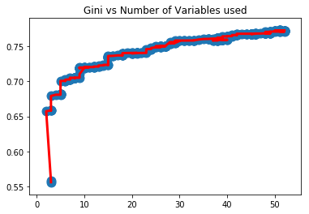

```python
graph_data = model_stats.loc[:,['Variables','KS','Gini']].reset_index(drop=True)

graph_data.Variables
no_vars=[]
for x in graph_data.Variables:
    no_vars.append(len(x))

graph_data['No_Vars']=pd.Series(no_vars)

y = graph_data.No_Vars
x = graph_data.Gini

plt.figure()
#plt.subplot(211)
plt.plot(y, x, 'r', lw=3)
plt.scatter(y, x, s=120)
plt.title('Gini vs Number of Variables used')

plt.show()
#plt.scatter(graph_data.loc[:,['Gini','No_Vars']])
```

# Gini of Test data

This step uses the variables of the results data to do a model fit based on the variables given. This is expected to be same model that was created during the iteration itself. The model is used to produce predictions on the training and test data. The variable selection fails if not enough iterations have been done. This step also saves the scored up test and training data for all models defined by the variable selections in a dataframe called model_data.

```python
print(model_stats.reset_index(drop=True).loc[20,['Variables']][0])
print(model_stats.reset_index(drop=True).loc[50,['Variables']][0])
print(model_stats.reset_index(drop=True).loc[100,['Variables']][0])
print(model_stats.reset_index(drop=True).loc[200,['Variables']][0])
print(model_stats.reset_index(drop=True).loc[len(model_stats.Variables)-1,['Variables']][0])

variable_selections = [model_stats.reset_index(drop=True).loc[20,['Variables']][0],
                      model_stats.reset_index(drop=True).loc[50,['Variables']][0],
                      model_stats.reset_index(drop=True).loc[100,['Variables']][0],
                      model_stats.reset_index(drop=True).loc[200,['Variables']][0],
                      model_stats.reset_index(drop=True).loc[len(model_stats.Variables)-1,['Variables']][0]]

#variable_selections = [['MIN_EX_E5_S_05_2_ALL_WoE', 'MIN_CC_OI_SCORE_WoE', 'SUM_char3425_WoE', 'AVG_435_CSLM_AVG_CURR_BAL_3_WoE', 'AVG_420_CA_MEB_CURR_BAL_1_WoE'], ['MIN_EX_E5_S_05_2_ALL_WoE', 'MIN_CC_OI_SCORE_WoE', 'AVG_char3140_WoE', 'SUM_435_CSLM_AVG_CURR_BAL_3_WoE', 'MAX_117_CLOSING_BALANCE_WoE', 'CC_MG_WoE', 'MIN_607_TIME_LAST_RETURNED_WoE', 'AVG_421_CA_AVG_CURR_BAL_3_WoE', 'MIN_char3425_WoE', 'AVG_607_TIME_LAST_RETURNED_WoE'], ['MIN_EX_E5_S_05_2_ALL_WoE', 'MIN_CC_OI_SCORE_WoE', 'AVG_char3140_WoE', 'SUM_435_CSLM_AVG_CURR_BAL_3_WoE', 'MAX_117_CLOSING_BALANCE_WoE', 'CC_MG_WoE', 'MIN_607_TIME_LAST_RETURNED_WoE', 'MIN_char3425_WoE', 'MIN_117_CLOSING_BALANCE_WoE', 'SUM_421_CA_AVG_CURR_BAL_3_WoE', 'SUM_5_AVERAGE_BALANCE_6_WoE', 'MIN_423_CA_HIGHEST_BAL_1_WoE', 'MIN_EQ_BIISF01_WoE', 'EQ_LSC558_WoE', 'AVG_18_DAYS_IN_EXCESS_6_WoE', 'SUM_EX_SP_F3_34_WoE', 'SUM_423_CA_HIGHEST_BAL_1_WoE'], ['MIN_EX_E5_S_05_2_ALL_WoE', 'MIN_CC_OI_SCORE_WoE', 'AVG_char3140_WoE', 'SUM_435_CSLM_AVG_CURR_BAL_3_WoE', 'MAX_117_CLOSING_BALANCE_WoE', 'CC_MG_WoE', 'MIN_607_TIME_LAST_RETURNED_WoE', 'MIN_char3425_WoE', 'MIN_117_CLOSING_BALANCE_WoE', 'SUM_421_CA_AVG_CURR_BAL_3_WoE', 'SUM_5_AVERAGE_BALANCE_6_WoE', 'MIN_423_CA_HIGHEST_BAL_1_WoE', 'MIN_EQ_BIISF01_WoE', 'EQ_LSC558_WoE', 'AVG_18_DAYS_IN_EXCESS_6_WoE', 'SUM_EX_SP_F3_34_WoE', 'AVG_69_CR_TOVER_LOWEST_1_WoE', 'MIN_6_LOWEST_BALANCE_1_WoE', 'MIN_606_TIME_LAST_PAID_REFER_WoE', 'AVG_9_HIGHEST_BALANCE_3_WoE', 'MIN_443_CSLM_AVG_POS_BAL_3_WoE', 'MIN_400_TIME_WITH_BANK_WoE', 'SUM_443_CSLM_AVG_POS_BAL_3_WoE']]

model_data = pd.DataFrame([])

for var_sel in variable_selections:
    variable_selection = var_sel #model_stats.reset_index(drop=True).loc[len(model_stats.Variables)-1,['Variables']][0]
    var_num=len(var_sel)
    x = regression_input[variable_selection].values       # independent variable
    y = regression_input['bad_flag'].values                      # dependent variable

    test2 = test[variable_selection+['bad_flag']].dropna().reset_index(drop=True)
    x_t = test2[variable_selection].values
    y_t = test2['bad_flag'].values

    #print(x)
    #print(y)

    # instantiate a logistic regression model, and fit with X and y
    model = LogisticRegression(warm_start = True)
    model = model.fit(x, y)

    # check the accuracy on the training set
    model.score(x, y)
    a = model.predict(x)
    b = model.predict_proba(x)[:,0]

    # Scoring up the data
    predictions = pd.DataFrame(model.predict(x))
    #probabilities = model.predict_log_proba(regression_input[variable_selection].values)[:,1]
    log_probabilities = model.predict_log_proba(regression_input[variable_selection].values)[:,1]
    #160 Evenscore, 20 PDO
    scores = (160 + (20 /np.log(2)) * (-log_probabilities))
    df_post1 = regression_input.loc[:,['bad_flag']].copy()
    df_post1['score'] = scores
    df_post1['model'] = 'model_'+str(var_num)+'train'

    df_post1['score'] = round(df_post1['score'])

    # check the accuracy on the test set
    model.score(x_t, y_t)
    a = model.predict(x_t)
    b = model.predict_proba(x_t)[:,0]

    # Scoring up the data
    predictions = pd.DataFrame(model.predict(x_t))
    #probabilities = model.predict_log_proba(regression_input[variable_selection].values)[:,1]
    log_probabilities = model.predict_log_proba(test2[variable_selection].values)[:,1]
    #160 Evenscore, 20 PDO
    scores = (160 + (20 /np.log(2)) * (-log_probabilities))
    df_post = test2.loc[:,['bad_flag']].copy()
    df_post['score'] = scores
    df_post['model'] = 'model_'+str(var_num)+'test'

    df_post['score'] = round(df_post['score'])

    df_post = df_post.sort_values(by='score',ascending=True).reset_index(drop=True)

    if model_data.empty:
        model_data = df_post1
        model_data = model_data.append(df_post)
    else:
        model_data = model_data.append(df_post1)
        model_data = model_data.append(df_post)

    print('test gini',len(var_sel),' ', abs(2*roc_auc_score(df_post.bad_flag, df_post.score)-1))
    print('train gini',len(var_sel),' ', abs(2*roc_auc_score(df_post1.bad_flag, df_post1.score)-1))
    #model.coef_
```

```
['AVG_EX_E5_S_05_2_ALL_WoE', 'MIN_436_CSL_MEB_CURR_BAL_1_WoE', 'MIN_CC_OI_SCORE_WoE', 'MAX_char3425_WoE', 'MAX_char3138_WoE', 'AVG_445_CSLM_AVG_CURR_BAL_3_WoE', 'AVG_420_CA_MEB_CURR_BAL_1_WoE']
['AVG_EX_E5_S_05_2_ALL_WoE', 'MIN_436_CSL_MEB_CURR_BAL_1_WoE', 'MIN_CC_OI_SCORE_WoE', 'MAX_char3425_WoE', 'AVG_char3140_WoE', 'MAX_117_CLOSING_BALANCE_WoE', 'CC_MG_WoE', 'MIN_607_TIME_LAST_RETURNED_WoE', 'AVG_607_TIME_LAST_RETURNED_WoE']
['AVG_EX_E5_S_05_2_ALL_WoE', 'MIN_436_CSL_MEB_CURR_BAL_1_WoE', 'MIN_CC_OI_SCORE_WoE', 'MAX_char3425_WoE', 'AVG_char3140_WoE', 'CC_MG_WoE', 'MIN_607_TIME_LAST_RETURNED_WoE', 'MIN_117_CLOSING_BALANCE_WoE', 'SUM_5_AVERAGE_BALANCE_6_WoE', 'MIN_EQ_BIISF01_WoE', 'EQ_LSC558_WoE', 'MAX_18_DAYS_IN_EXCESS_6_W…
['AVG_EX_E5_S_05_2_ALL_WoE', 'MIN_436_CSL_MEB_CURR_BAL_1_WoE', 'MIN_CC_OI_SCORE_WoE', 'MAX_char3425_WoE', 'AVG_char3140_WoE', 'CC_MG_WoE', 'MIN_607_TIME_LAST_RETURNED_WoE', 'MIN_117_CLOSING_BALANCE_WoE', 'SUM_5_AVERAGE_BALANCE_6_WoE', 'MIN_EQ_BIISF01_WoE', 'MAX_18_DAYS_IN_EXCESS_6_WoE', 'SUM_EX_SP_F…
['AVG_EX_E5_S_05_2_ALL_WoE', 'MIN_436_CSL_MEB_CURR_BAL_1_WoE', 'MIN_CC_OI_SCORE_WoE', 'MAX_char3425_WoE', 'AVG_char3140_WoE', 'MIN_607_TIME_LAST_RETURNED_WoE', 'MIN_117_CLOSING_BALANCE_WoE', 'MIN_EQ_BIISF01_WoE', 'MAX_18_DAYS_IN_EXCESS_6_WoE', 'SUM_EX_SP_F3_34_WoE', 'AVG_69_CR_TOVER_LOWEST_1_WoE', '…
test gini 7   0.692058395734
train gini 7   0.703696087595
test gini 9   0.710832049711
train gini 9   0.718906022414
test gini 21   0.731870493107
train gini 21   0.74003673714
test gini 38   0.752607573202
train gini 38   0.761388968289
test gini 51   0.764182517254
train gini 51   0.772312960604
```

```python
model_data
```

|  | bad_flag | score | model |
| --- | --- | --- | --- |
| 9678 | 0 | 211.0 | model_7train |
| 9455 | 0 | 258.0 | model_7train |
| 48255 | 0 | 249.0 | model_7train |
| 27611 | 0 | 257.0 | model_7train |
| 12759 | 1 | 166.0 | model_7train |
| 15333 | 0 | 200.0 | model_7train |
| 41264 | 1 | 172.0 | model_7train |
| 3739 | 0 | 238.0 | model_7train |
| 50179 | 0 | 172.0 | model_7train |
| 38251 | 1 | 184.0 | model_7train |
| 8002 | 0 | 230.0 | model_7train |
| 38256 | 1 | 168.0 | model_7train |
| 38939 | 0 | 215.0 | model_7train |
| 20150 | 1 | 255.0 | model_7train |
| 424 | 0 | 200.0 | model_7train |
| 26734 | 0 | 198.0 | model_7train |
| 49574 | 0 | 249.0 | model_7train |
| 48164 | 0 | 257.0 | model_7train |
| 6284 | 0 | 255.0 | model_7train |
| 38090 | 0 | 202.0 | model_7train |
| 31233 | 0 | 254.0 | model_7train |
| 8914 | 1 | 171.0 | model_7train |
| 34901 | 0 | 178.0 | model_7train |
| 27550 | 0 | 258.0 | model_7train |
| 52460 | 0 | 204.0 | model_7train |
| 11118 | 0 | 263.0 | model_7train |
| 19696 | 0 | 203.0 | model_7train |
| 12737 | 0 | 237.0 | model_7train |
| 37320 | 0 | 174.0 | model_7train |
| 47677 | 0 | 258.0 | model_7train |
| ... | ... | ... | ... |
| 15731 | 0 | 306.0 | model_51test |
| 15732 | 0 | 306.0 | model_51test |
| 15733 | 0 | 306.0 | model_51test |
| 15734 | 0 | 307.0 | model_51test |
| 15735 | 0 | 307.0 | model_51test |
| 15736 | 0 | 307.0 | model_51test |
| 15737 | 0 | 308.0 | model_51test |
| 15738 | 0 | 308.0 | model_51test |
| 15739 | 0 | 308.0 | model_51test |
| 15740 | 0 | 309.0 | model_51test |
| 15741 | 0 | 309.0 | model_51test |
| 15742 | 0 | 309.0 | model_51test |
| 15743 | 0 | 309.0 | model_51test |
| 15744 | 0 | 309.0 | model_51test |
| 15745 | 0 | 309.0 | model_51test |
| 15746 | 0 | 310.0 | model_51test |
| 15747 | 0 | 310.0 | model_51test |
| 15748 | 1 | 311.0 | model_51test |
| 15749 | 0 | 311.0 | model_51test |
| 15750 | 1 | 312.0 | model_51test |
| 15751 | 0 | 312.0 | model_51test |
| 15752 | 0 | 312.0 | model_51test |
| 15753 | 0 | 312.0 | model_51test |
| 15754 | 0 | 313.0 | model_51test |
| 15755 | 0 | 313.0 | model_51test |
| 15756 | 0 | 314.0 | model_51test |
| 15757 | 0 | 319.0 | model_51test |
| 15758 | 0 | 320.0 | model_51test |
| 15759 | 0 | 321.0 | model_51test |
| 15760 | 0 | 330.0 | model_51test |

261568 rows × 3 columns

# Score Distribution

```
test data              score bad_flag
                      count     sum
0  (159.83, 177.0]     2712  1976.0
1   (177.0, 194.0]     1898   881.0
2   (194.0, 211.0]     1710   406.0
3   (211.0, 228.0]     1898   236.0
4   (228.0, 245.0]     2276   127.0
5   (245.0, 262.0]     2345    91.0
6   (262.0, 279.0]     2015    38.0
7   (279.0, 296.0]      775    13.0
8   (296.0, 313.0]      127     4.0
9   (313.0, 330.0]        5     0.0
training data:               score bad_flag
                       count     sum
0  (159.827, 177.3]     6416  4790.0
1    (177.3, 194.6]     4360  1930.0
2    (194.6, 211.9]     4044   995.0
3    (211.9, 229.2]     4604   546.0
4    (229.2, 246.5]     5233   289.0
5    (246.5, 263.8]     5256   177.0
6    (263.8, 281.1]     4792    94.0
7    (281.1, 298.4]     1595    28.0
8    (298.4, 315.7]      230     1.0
9    (315.7, 333.0]       11     0.0
```

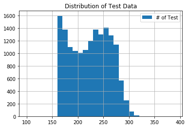

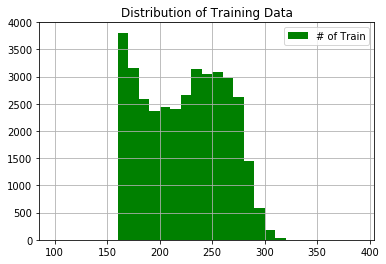

```python
# check the accuracy on the training set
plt.show()
# print(df_post.loc[:,['score','bad_flag']])
# plt.scatter(b,a)

bins = np.linspace(df_post.score.min(), df_post.score.max(), 20)
#print(bins)

#groups = df.groupby(pandas.cut(df.a, bins))

distribution = df_post.loc[:,['bad_flag']].groupby(pd.cut(df_post.score, 10 ),as_index=False).agg(['count','sum']).reset_index(drop=False)
distribution1 = df_post1.loc[:,['bad_flag']].groupby(pd.cut(df_post1.score, 10 ),as_index=False).agg(['count','sum']).reset_index(drop=False)
#distribution['bad_rate'] = distribution['sum'] / distribution['count']
print('test data',distribution)
print('training data:', distribution1)

plt.show()
df_post.loc[:,['score']].hist(bins=range(100,400,10), label='# of Test')
plt.title('Distribution of Test Data')
plt.legend(prop={'size': 10})
plt.show()

df_post1.loc[:,['score']].hist(bins=range(100,400,10), label='# of Train', color = 'green')
plt.title('Distribution of Training Data')
plt.legend(prop={'size': 10})
plt.show()
```

# KS Plot

```
KS at Score: 202.0
KS =  0.62
```

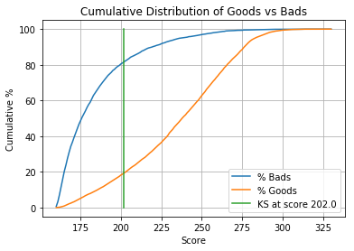

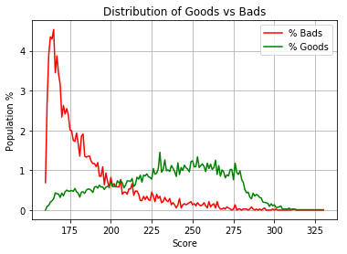

```python
# taking a subset to keep things simple for functionalisation
# bad flag can be a generic indicator whether the row belongs to distribution 1 or 2
# score is an identifier of the distribution x - axis
# a weight has to be added if input data is already grouped up
sample = df_post.loc[:,['bad_flag','score']].copy()

# sort to have right order
sample.sort_values(by='score')

# grouping by score and dropping level to get columns
# assuming no missing values count gives # of distribution1+2, sum just # of distribution 1
# count-sum gives # of distribution 2
distr = sample.groupby('score').agg(['count','sum'])
distr.columns = distr.columns.droplevel(0)
distr['dis1'] = distr['sum']
distr['dis2'] = distr['count'] - distr['sum']

# calculating cumulative percentages
distr['dis1_cum_sum'] = distr.dis1.cumsum()
distr['dis1_perc'] = distr.dis1 / distr.dis1.sum()
distr['dis1_cum_perc'] = distr.dis1_cum_sum/distr.dis1.sum()

distr['dis2_cum_sum'] = distr.dis2.cumsum()
distr['dis2_perc'] = distr.dis2 / distr.dis2.sum()
distr['dis2_cum_perc'] = distr.dis2_cum_sum/distr.dis2.sum()

# calculating KS
distr['KS'] = distr['dis1_cum_perc'] - distr['dis2_cum_perc']
KS_value = distr.KS.max()
KS_score = distr.loc[distr['KS']==KS_value].reset_index().loc[0,'score']
print('KS at Score:',KS_score)

# show results

print('KS = ',round(KS_value,2))

KS_spot = pd.DataFrame([0,100],[KS_score,KS_score])

plt.show()
plt.plot(distr.loc[:,['dis1_cum_perc']]*100, label='% Bads')
plt.plot(distr.loc[:,['dis2_cum_perc']]*100, label='% Goods')
plt.plot(KS_spot,label='KS at score '+str(KS_score))
plt.title('Cumulative Distribution of Goods vs Bads')
plt.legend(prop={'size': 10})
plt.xlabel('Score')
plt.ylabel('Cumulative %')
#plt.yaxis.set_major_formatter(FuncFormatter('{0:.0%}'.format))
plt.grid(True)
plt.show()

plt.plot(distr.loc[:,['dis1_perc']]*100, label='% Bads', color='red')
plt.plot(distr.loc[:,['dis2_perc']]*100, label='% Goods', color='green')
plt.title('Distribution of Goods vs Bads')
plt.legend(prop={'size': 10})
plt.xlabel('Score')
plt.ylabel('Population %')
plt.grid(True)
plt.show()
```

# Cumulative Score Distribution Plots

For all Good/Bad Distrbutions of all models, Test and Train

```
These are the models list_of_models
```

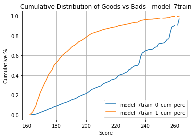

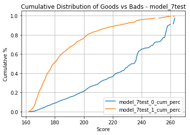

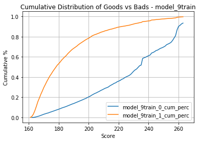

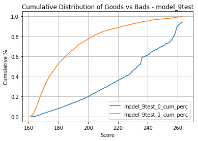

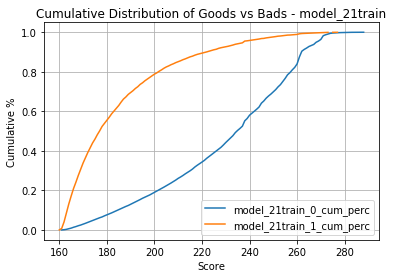

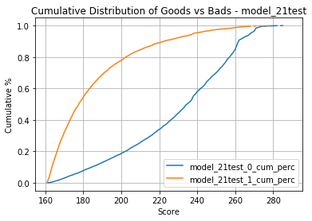

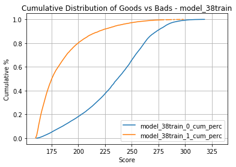

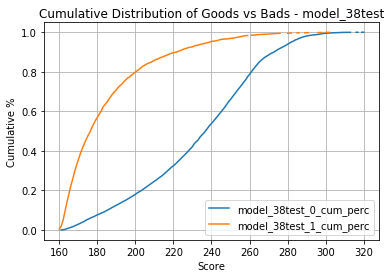

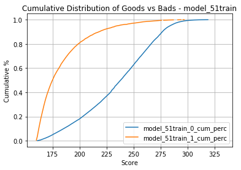

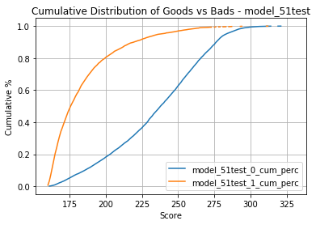

| model_descriptor score | model_21test_0 | model_21test_1 | model_21train_0 | model_21train_1 | model_38test_0 | model_38test_1 | model_38train_0 | model_38train_1 | model_51test_0 | model_51test_1 | ... | model_7train_1_perc | model_7train_1_cum_perc | model_9test_0_perc | model_9test_0_cum_perc | model_9test_1_perc | model_9test_1_cum_perc | model_9train_0_perc | model_9train_0_cum_perc | model_9train_1_perc | model_9train_1_cum_perc |
| --- | --- | --- | --- | --- | --- | --- | --- | --- | --- | --- | --- | --- | --- | --- | --- | --- | --- | --- | --- | --- | --- |
| 160.0 | NaN | NaN | NaN | 1.0 | NaN | 16.0 | NaN | 19.0 | NaN | 26.0 | ... | NaN | NaN | NaN | NaN | NaN | NaN | NaN | NaN | NaN | NaN |
| 161.0 | 1.0 | 22.0 | 2.0 | 65.0 | 8.0 | 59.0 | 10.0 | 190.0 | 11.0 | 101.0 | ... | NaN | NaN | NaN | NaN | 0.000795 | 0.000795 | NaN | NaN | 0.000452 | 0.000452 |
| 162.0 | 11.0 | 120.0 | 27.0 | 293.0 | 12.0 | 113.0 | 34.0 | 376.0 | 14.0 | 147.0 | ... | 0.001017 | 0.001017 | 0.000167 | 0.000167 | 0.010604 | 0.011400 | 0.000144 | 0.000144 | 0.009492 | 0.009944 |
| 163.0 | 23.0 | 162.0 | 53.0 | 412.0 | 22.0 | 172.0 | 60.0 | 440.0 | 24.0 | 164.0 | ... | 0.013559 | 0.014576 | 0.000833 | 0.000999 | 0.014316 | 0.025716 | 0.000578 | 0.000722 | 0.021921 | 0.031864 |
| 164.0 | 40.0 | 164.0 | 82.0 | 393.0 | 38.0 | 167.0 | 64.0 | 379.0 | 28.0 | 162.0 | ... | 0.015819 | 0.030395 | 0.001998 | 0.002997 | 0.028632 | 0.054348 | 0.001986 | 0.002708 | 0.034576 | 0.066441 |
| 165.0 | 44.0 | 131.0 | 90.0 | 356.0 | 42.0 | 150.0 | 95.0 | 383.0 | 34.0 | 171.0 | ... | 0.031073 | 0.061469 | 0.003413 | 0.006410 | 0.039236 | 0.093584 | 0.003611 | 0.006320 | 0.042373 | 0.108814 |
| 166.0 | 41.0 | 139.0 | 120.0 | 336.0 | 38.0 | 160.0 | 96.0 | 318.0 | 52.0 | 130.0 | ... | 0.027006 | 0.088475 | 0.005245 | 0.011655 | 0.040032 | 0.133616 | 0.003936 | 0.010256 | 0.046554 | 0.155367 |
| 167.0 | 50.0 | 138.0 | 97.0 | 284.0 | 38.0 | 128.0 | 96.0 | 293.0 | 49.0 | 146.0 | ... | 0.051299 | 0.139774 | 0.003996 | 0.015651 | 0.038971 | 0.172587 | 0.004406 | 0.014662 | 0.035706 | 0.191073 |
| 168.0 | 53.0 | 129.0 | 118.0 | 301.0 | 51.0 | 141.0 | 130.0 | 298.0 | 48.0 | 129.0 | ... | 0.036158 | 0.175932 | 0.006077 | 0.021728 | 0.037646 | 0.210233 | 0.005742 | 0.020404 | 0.037853 | 0.228927 |
| 169.0 | 46.0 | 97.0 | 97.0 | 276.0 | 47.0 | 122.0 | 96.0 | 299.0 | 38.0 | 119.0 | ... | 0.047910 | 0.223842 | 0.005411 | 0.027140 | 0.035790 | 0.246023 | 0.005345 | 0.025748 | 0.032542 | 0.261469 |
| 170.0 | 59.0 | 114.0 | 116.0 | 277.0 | 52.0 | 111.0 | 110.0 | 271.0 | 51.0 | 88.0 | ... | 0.031751 | 0.255593 | 0.004579 | 0.031718 | 0.037646 | 0.283669 | 0.005923 | 0.031671 | 0.035141 | 0.296610 |
| 171.0 | 52.0 | 103.0 | 127.0 | 236.0 | 57.0 | 111.0 | 115.0 | 257.0 | 43.0 | 99.0 | ... | 0.033107 | 0.288701 | 0.005744 | 0.037463 | 0.030753 | 0.314422 | 0.004731 | 0.036402 | 0.028927 | 0.325537 |
| 172.0 | 58.0 | 96.0 | 131.0 | 238.0 | 62.0 | 95.0 | 130.0 | 236.0 | 55.0 | 91.0 | ... | 0.034011 | 0.322712 | 0.004662 | 0.042125 | 0.033404 | 0.347826 | 0.004731 | 0.041132 | 0.030282 | 0.355819 |
| 173.0 | 62.0 | 97.0 | 124.0 | 212.0 | 51.0 | 85.0 | 111.0 | 235.0 | 60.0 | 96.0 | ... | 0.025650 | 0.348362 | 0.004329 | 0.046454 | 0.028897 | 0.376723 | 0.003720 | 0.044852 | 0.026893 | 0.382712 |
| 174.0 | 45.0 | 99.0 | 136.0 | 214.0 | 75.0 | 90.0 | 124.0 | 197.0 | 57.0 | 90.0 | ... | 0.033446 | 0.381808 | 0.004912 | 0.051365 | 0.024655 | 0.401379 | 0.005959 | 0.050811 | 0.027119 | 0.409831 |
| 175.0 | 52.0 | 88.0 | 139.0 | 172.0 | 55.0 | 73.0 | 150.0 | 218.0 | 57.0 | 76.0 | ... | 0.033220 | 0.415028 | 0.004496 | 0.055861 | 0.021474 | 0.422853 | 0.004731 | 0.055542 | 0.021243 | 0.431073 |
| 176.0 | 63.0 | 77.0 | 114.0 | 199.0 | 60.0 | 67.0 | 137.0 | 175.0 | 59.0 | 75.0 | ... | 0.017627 | 0.432655 | 0.006077 | 0.061938 | 0.022534 | 0.445387 | 0.005309 | 0.060850 | 0.024181 | 0.455254 |
| 177.0 | 40.0 | 64.0 | 136.0 | 174.0 | 53.0 | 85.0 | 143.0 | 173.0 | 56.0 | 66.0 | ... | 0.019435 | 0.452090 | 0.004412 | 0.066350 | 0.019088 | 0.464475 | 0.005309 | 0.066159 | 0.021130 | 0.476384 |
| 178.0 | 61.0 | 84.0 | 113.0 | 195.0 | 44.0 | 73.0 | 131.0 | 146.0 | 65.0 | 65.0 | ... | 0.040904 | 0.492994 | 0.005661 | 0.072011 | 0.022269 | 0.486744 | 0.005381 | 0.071539 | 0.021356 | 0.497740 |
| 179.0 | 68.0 | 67.0 | 154.0 | 136.0 | 59.0 | 71.0 | 133.0 | 152.0 | 55.0 | 73.0 | ... | 0.021469 | 0.514463 | 0.004662 | 0.076673 | 0.022800 | 0.509544 | 0.005381 | 0.076920 | 0.020113 | 0.517853 |
| 180.0 | 61.0 | 64.0 | 135.0 | 140.0 | 51.0 | 62.0 | 139.0 | 121.0 | 51.0 | 63.0 | ... | 0.012768 | 0.527232 | 0.005328 | 0.082001 | 0.017232 | 0.526776 | 0.004586 | 0.081507 | 0.015367 | 0.533220 |
| 181.0 | 71.0 | 75.0 | 127.0 | 135.0 | 46.0 | 59.0 | 126.0 | 129.0 | 39.0 | 51.0 | ... | 0.016045 | 0.543277 | 0.005411 | 0.087413 | 0.019618 | 0.546394 | 0.005706 | 0.087212 | 0.016836 | 0.550056 |
| 182.0 | 56.0 | 61.0 | 148.0 | 152.0 | 52.0 | 60.0 | 123.0 | 121.0 | 54.0 | 70.0 | ... | 0.021356 | 0.564633 | 0.005495 | 0.092907 | 0.015111 | 0.561506 | 0.006573 | 0.093785 | 0.019322 | 0.569379 |
| 183.0 | 61.0 | 54.0 | 153.0 | 127.0 | 55.0 | 78.0 | 128.0 | 116.0 | 55.0 | 72.0 | ... | 0.018644 | 0.583277 | 0.004912 | 0.097819 | 0.013256 | 0.574761 | 0.004839 | 0.098624 | 0.015028 | 0.584407 |
| 184.0 | 51.0 | 55.0 | 153.0 | 133.0 | 56.0 | 43.0 | 142.0 | 119.0 | 50.0 | 51.0 | ... | 0.018983 | 0.602260 | 0.005078 | 0.102897 | 0.013256 | 0.588017 | 0.004911 | 0.103535 | 0.015593 | 0.600000 |
| 185.0 | 67.0 | 64.0 | 155.0 | 114.0 | 69.0 | 45.0 | 130.0 | 114.0 | 60.0 | 50.0 | ... | 0.011864 | 0.614124 | 0.006660 | 0.109557 | 0.014316 | 0.602333 | 0.005453 | 0.108988 | 0.013107 | 0.613107 |
| 186.0 | 54.0 | 45.0 | 143.0 | 152.0 | 60.0 | 56.0 | 142.0 | 107.0 | 63.0 | 51.0 | ... | 0.015254 | 0.629379 | 0.005245 | 0.114802 | 0.016172 | 0.618505 | 0.006175 | 0.115164 | 0.018192 | 0.631299 |
| 187.0 | 57.0 | 50.0 | 149.0 | 137.0 | 58.0 | 50.0 | 166.0 | 115.0 | 63.0 | 51.0 | ... | 0.007684 | 0.637062 | 0.005661 | 0.120463 | 0.016172 | 0.634677 | 0.006031 | 0.121195 | 0.015028 | 0.646328 |
| 188.0 | 70.0 | 54.0 | 154.0 | 93.0 | 72.0 | 54.0 | 138.0 | 108.0 | 59.0 | 46.0 | ... | 0.014802 | 0.651864 | 0.005744 | 0.126207 | 0.013256 | 0.647932 | 0.006284 | 0.127478 | 0.014237 | 0.660565 |
| 189.0 | 67.0 | 40.0 | 133.0 | 115.0 | 60.0 | 41.0 | 136.0 | 110.0 | 53.0 | 44.0 | ... | 0.013672 | 0.665537 | 0.006327 | 0.132534 | 0.011400 | 0.659332 | 0.005814 | 0.133292 | 0.013672 | 0.674237 |
| ... | ... | ... | ... | ... | ... | ... | ... | ... | ... | ... | ... | ... | ... | ... | ... | ... | ... | ... | ... | ... | ... |
| 299.0 | NaN | NaN | NaN | NaN | 14.0 | NaN | 24.0 | NaN | 13.0 | 1.0 | ... | NaN | NaN | NaN | NaN | NaN | NaN | NaN | NaN | NaN | NaN |
| 300.0 | NaN | NaN | NaN | NaN | 13.0 | 1.0 | 28.0 | NaN | 16.0 | NaN | ... | NaN | NaN | NaN | NaN | NaN | NaN | NaN | NaN | NaN | NaN |
| 301.0 | NaN | NaN | NaN | NaN | 5.0 | 1.0 | 27.0 | NaN | 8.0 | 1.0 | ... | NaN | NaN | NaN | NaN | NaN | NaN | NaN | NaN | NaN | NaN |
| 302.0 | NaN | NaN | NaN | NaN | 12.0 | 1.0 | 26.0 | 3.0 | 8.0 | NaN | ... | NaN | NaN | NaN | NaN | NaN | NaN | NaN | NaN | NaN | NaN |
| 303.0 | NaN | NaN | NaN | NaN | 6.0 | NaN | 25.0 | NaN | 10.0 | NaN | ... | NaN | NaN | NaN | NaN | NaN | NaN | NaN | NaN | NaN | NaN |
| 304.0 | NaN | NaN | NaN | NaN | 6.0 | NaN | 22.0 | NaN | 12.0 | NaN | ... | NaN | NaN | NaN | NaN | NaN | NaN | NaN | NaN | NaN | NaN |
| 305.0 | NaN | NaN | NaN | NaN | 10.0 | NaN | 12.0 | NaN | 3.0 | NaN | ... | NaN | NaN | NaN | NaN | NaN | NaN | NaN | NaN | NaN | NaN |
| 306.0 | NaN | NaN | NaN | NaN | 7.0 | NaN | 13.0 | NaN | 3.0 | NaN | ... | NaN | NaN | NaN | NaN | NaN | NaN | NaN | NaN | NaN | NaN |
| 307.0 | NaN | NaN | NaN | NaN | 4.0 | NaN | 7.0 | NaN | 3.0 | NaN | ... | NaN | NaN | NaN | NaN | NaN | NaN | NaN | NaN | NaN | NaN |
| 308.0 | NaN | NaN | NaN | NaN | 2.0 | NaN | 12.0 | NaN | 3.0 | NaN | ... | NaN | NaN | NaN | NaN | NaN | NaN | NaN | NaN | NaN | NaN |
| 309.0 | NaN | NaN | NaN | NaN | 1.0 | NaN | 5.0 | NaN | 6.0 | NaN | ... | NaN | NaN | NaN | NaN | NaN | NaN | NaN | NaN | NaN | NaN |
| 310.0 | NaN | NaN | NaN | NaN | 2.0 | NaN | 7.0 | NaN | 2.0 | NaN | ... | NaN | NaN | NaN | NaN | NaN | NaN | NaN | NaN | NaN | NaN |
| 311.0 | NaN | NaN | NaN | NaN | 1.0 | NaN | 8.0 | NaN | 1.0 | 1.0 | ... | NaN | NaN | NaN | NaN | NaN | NaN | NaN | NaN | NaN | NaN |
| 312.0 | NaN | NaN | NaN | NaN | 1.0 | 1.0 | 3.0 | NaN | 3.0 | 1.0 | ... | NaN | NaN | NaN | NaN | NaN | NaN | NaN | NaN | NaN | NaN |
| 313.0 | NaN | NaN | NaN | NaN | 1.0 | NaN | 4.0 | NaN | 2.0 | NaN | ... | NaN | NaN | NaN | NaN | NaN | NaN | NaN | NaN | NaN | NaN |
| 314.0 | NaN | NaN | NaN | NaN | NaN | 1.0 | 4.0 | NaN | 1.0 | NaN | ... | NaN | NaN | NaN | NaN | NaN | NaN | NaN | NaN | NaN | NaN |
| 315.0 | NaN | NaN | NaN | NaN | NaN | NaN | 2.0 | NaN | NaN | NaN | ... | NaN | NaN | NaN | NaN | NaN | NaN | NaN | NaN | NaN | NaN |
| 316.0 | NaN | NaN | NaN | NaN | 2.0 | NaN | 2.0 | NaN | NaN | NaN | ... | NaN | NaN | NaN | NaN | NaN | NaN | NaN | NaN | NaN | NaN |
| 317.0 | NaN | NaN | NaN | NaN | 1.0 | NaN | 1.0 | NaN | NaN | NaN | ... | NaN | NaN | NaN | NaN | NaN | NaN | NaN | NaN | NaN | NaN |
| 318.0 | NaN | NaN | NaN | NaN | NaN | NaN | 4.0 | NaN | NaN | NaN | ... | NaN | NaN | NaN | NaN | NaN | NaN | NaN | NaN | NaN | NaN |
| 319.0 | NaN | NaN | NaN | NaN | 1.0 | NaN | NaN | 1.0 | 1.0 | NaN | ... | NaN | NaN | NaN | NaN | NaN | NaN | NaN | NaN | NaN | NaN |
| 320.0 | NaN | NaN | NaN | NaN | 1.0 | NaN | 3.0 | NaN | 1.0 | NaN | ... | NaN | NaN | NaN | NaN | NaN | NaN | NaN | NaN | NaN | NaN |
| 321.0 | NaN | NaN | NaN | NaN | NaN | NaN | NaN | NaN | 1.0 | NaN | ... | NaN | NaN | NaN | NaN | NaN | NaN | NaN | NaN | NaN | NaN |
| 323.0 | NaN | NaN | NaN | NaN | NaN | NaN | 1.0 | NaN | NaN | NaN | ... | NaN | NaN | NaN | NaN | NaN | NaN | NaN | NaN | NaN | NaN |
| 324.0 | NaN | NaN | NaN | NaN | NaN | NaN | NaN | NaN | NaN | NaN | ... | NaN | NaN | NaN | NaN | NaN | NaN | NaN | NaN | NaN | NaN |
| 328.0 | NaN | NaN | NaN | NaN | NaN | NaN | 1.0 | NaN | NaN | NaN | ... | NaN | NaN | NaN | NaN | NaN | NaN | NaN | NaN | NaN | NaN |
| 329.0 | NaN | NaN | NaN | NaN | NaN | NaN | NaN | NaN | NaN | NaN | ... | NaN | NaN | NaN | NaN | NaN | NaN | NaN | NaN | NaN | NaN |
| 330.0 | NaN | NaN | NaN | NaN | NaN | NaN | NaN | NaN | 1.0 | NaN | ... | NaN | NaN | NaN | NaN | NaN | NaN | NaN | NaN | NaN | NaN |
| 331.0 | NaN | NaN | NaN | NaN | NaN | NaN | 1.0 | NaN | NaN | NaN | ... | NaN | NaN | NaN | NaN | NaN | NaN | NaN | NaN | NaN | NaN |
| 333.0 | NaN | NaN | NaN | NaN | NaN | NaN | NaN | NaN | NaN | NaN | ... | NaN | NaN | NaN | NaN | NaN | NaN | NaN | NaN | NaN | NaN |

169 rows × 61 columns

```python
# creating a single model identifier
model_data['model_descriptor'] = model_data['model']+'_'+model_data['bad_flag'].astype(str)
# creating a list of models that will each be plotted
list_of_models = model_data.model.unique()
print('These are the models list_of_models')

# creating a single dataset with the score as index and observation volumes for each model
graph_data = model_data.drop(['bad_flag','model'], axis = 1)\
    .pivot_table(index='score', columns='model_descriptor', values='score', aggfunc=len)

# calculating the % and cumulative % for each column/model
for x in graph_data.columns:
    graph_data['cum_sum'] = graph_data[x].cumsum()
    graph_data[x+'_perc'] = graph_data[x] / graph_data[x].sum()
    graph_data[x+'_cum_perc'] = graph_data['cum_sum']/graph_data[x].sum()

# deciding which columns should be plotted
chart_cols = [x for x in graph_data.columns if 'cum_perc' in x]
chart_cols = [x for x in chart_cols if 'cum_perc' in x]

# plotting all
plt.show()
for y in list_of_models:
    plt.show()
    for x in [x for x in chart_cols if y in x]:
        plt.plot(graph_data.loc[:,x])
    plt.title('Cumulative Distribution of Goods vs Bads - '+y)
    plt.legend(prop={'size': 10})
    plt.xlabel('Score')
    plt.ylabel('Cumulative %')
    #plt.yaxis.set_major_formatter(FuncFormatter('{0:.0%}'.format))
    plt.grid(True)
    plt.show()

stepwise_data = graph_data.copy()
stepwise_data
```

```python
#download
#stats_run400.to_csv('stats_run400',sep=',')
```

# Comparison to Incumbent Model

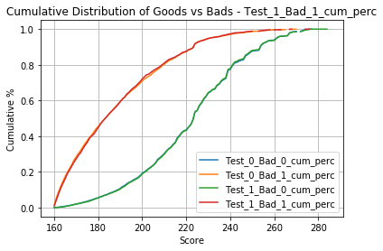

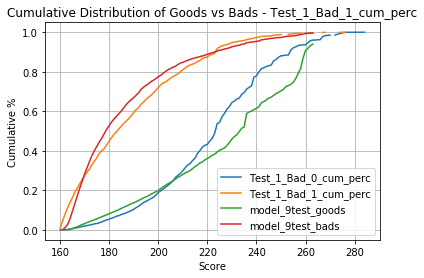

```python
incumbent_data = pd.read_csv("incumbent.csv",low_memory=False)
incumbent_data['score'] = round(incumbent_data['scores'])
incumbent_data = incumbent_data[['score','bad_flag','test_flag']]#.set_index('score')
incumbent_data['model_descriptor'] = 'Test_' + incumbent_data['test_flag'].astype(str) + '_' \
    + 'Bad_' +incumbent_data['bad_flag'].astype(str)

graph_data = incumbent_data.pivot_table(index='score', columns='model_descriptor', values='bad_flag', aggfunc=len)

# calculating the % and cumulative % for each column/model
for x in graph_data.columns:
    graph_data['cum_sum'] = graph_data[x].cumsum()
    graph_data[x+'_perc'] = graph_data[x] / graph_data[x].sum()
    graph_data[x+'_cum_perc'] = graph_data['cum_sum']/graph_data[x].sum()

# deciding which columns should be plotted
chart_cols = [x for x in graph_data.columns if 'cum_perc' in x]
#chart_cols = [x for x in chart_cols if 'Test_1' in x]

# plotting all
plt.show()
for x in chart_cols:
    plt.plot(graph_data.loc[:,x])
plt.title('Cumulative Distribution of Goods vs Bads - '+x)
plt.legend(prop={'size': 10})
plt.xlabel('Score')
plt.ylabel('Cumulative %')
#plt.yaxis.set_major_formatter(FuncFormatter('{0:.0%}'.format))
plt.grid(True)
plt.show()

# deciding which columns should be plotted
chart_cols = [x for x in graph_data.columns if 'cum_perc' in x]
chart_cols = [x for x in chart_cols if 'Test_1' in x]

# plotting all
plt.show()
for x in chart_cols:
    plt.plot(graph_data.loc[:,x])

plt.plot(stepwise_data.loc[:,'model_9test_0_cum_perc'],label = 'model_9test_goods')
plt.plot(stepwise_data.loc[:,'model_9test_1_cum_perc'],label = 'model_9test_bads')
plt.title('Cumulative Distribution of Goods vs Bads - '+x)
plt.legend(prop={'size': 10})
plt.xlabel('Score')
plt.ylabel('Cumulative %')
#plt.yaxis.set_major_formatter(FuncFormatter('{0:.0%}'.format))
plt.grid(True)
plt.show()

incumbent_graph_data = graph_data
```

# Comparison to Lasso

Logistic regression model built with 13 variables.

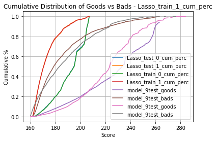

```python
lasso_data = pd.read_csv("lasso_results.csv",low_memory=False)
lasso_data = lasso_data[['score','bad_flag','model']]
lasso_data['model_descriptor'] = 'Lasso_' + lasso_data['model'].astype(str) + '_' \
    +lasso_data['bad_flag'].astype(str)

graph_data = lasso_data.pivot_table(index='score', columns='model_descriptor', values='bad_flag', aggfunc=len)

# calculating the % and cumulative % for each column/model
for x in graph_data.columns:
    graph_data['cum_sum'] = graph_data[x].cumsum()
    graph_data[x+'_perc'] = graph_data[x] / graph_data[x].sum()
    graph_data[x+'_cum_perc'] = graph_data['cum_sum']/graph_data[x].sum()

chart_cols = [x for x in graph_data.columns if 'cum_perc' in x]

# plotting all
plt.show()
for x in chart_cols:
    plt.plot(graph_data.loc[:,x])

plt.plot(stepwise_data.loc[:,'model_9test_0_cum_perc'],label = 'model_9test_goods')
plt.plot(stepwise_data.loc[:,'model_9test_1_cum_perc'],label = 'model_9test_bads')
plt.plot(incumbent_graph_data.loc[:,'Test_1_Bad_0_cum_perc'],label = 'model_9test_goods')
plt.plot(incumbent_graph_data.loc[:,'Test_1_Bad_1_cum_perc'],label = 'model_9test_bads')
plt.title('Cumulative Distribution of Goods vs Bads - '+x)
plt.legend(prop={'size': 10})
plt.xlabel('Score')
plt.ylabel('Cumulative %')
#plt.yaxis.set_major_formatter(FuncFormatter('{0:.0%}'.format))
plt.grid(True)
plt.show()
#graph_data
```

```python
# deciding which columns should be plotted
chart_cols = [x for x in graph_data.columns if 'cum_perc' in x]
chart_cols = [x for x in chart_cols if 'cum_perc' in x]

# plotting all
plt.show()
for x in chart_cols:
    plt.plot(graph_data.loc[:,x])

plt.plot(stepwise_data.loc[:,'model_9test_0_cum_perc'],label = 'model_9test_goods')
plt.plot(stepwise_data.loc[:,'model_9test_1_cum_perc'],label = 'model_9test_bads')
plt.title('Cumulative Distribution of Goods vs Bads - '+x)
plt.legend(prop={'size': 10})
plt.xlabel('Score')
plt.ylabel('Cumulative %')
#plt.yaxis.set_major_formatter(FuncFormatter('{0:.0%}'.format))
plt.grid(True)
plt.show()

graph_data
```

[output not shown]

[output cut: 16 more lines]

[output not shown]